# 6. Analysis of longitudinal data

```r
date()
```

```
## [1] "Wed Dec 02 15:15:46 2020"
```

This week I learned something about the analysis of longitudinal data. Below you can find the analysis that was performed, more information about the data that was analyzed and the results I got.

Useful libraries:

```r
library(dplyr)
```

```r
library(tidyr)
library(ggplot2)
```

### Analysis of RATS data

RATS data consists of results from a nutrition study conducted in three groups of rats which were put on a different diet and their body weights were recorded repeatedly over a nine week period (Crowder and Hand 1990). And now I will look if there are any differences between those groups.

Here is the RATS data that was wrangled in a long form:

```r
RATSL <- read.table("~/R/IODS-course/IODS-project/Data/RATSL.txt", sep = " ", header=TRUE)
glimpse(RATSL)
```

```
## Rows: 176
## Columns: 5
## $ ID     <int> 1, 2, 3, 4, 5, 6, 7, 8, 9, 10, 11, 12, 13, 14, 15, 16, 1, 2,...
## $ Group  <int> 1, 1, 1, 1, 1, 1, 1, 1, 2, 2, 2, 2, 3, 3, 3, 3, 1, 1, 1, 1, ...
## $ WD     <chr> "WD1", "WD1", "WD1", "WD1", "WD1", "WD1", "WD1", "WD1", "WD1...
## $ Weight <int> 240, 225, 245, 260, 255, 260, 275, 245, 410, 405, 445, 555, ...
## $ Time   <int> 1, 1, 1, 1, 1, 1, 1, 1, 1, 1, 1, 1, 1, 1, 1, 1, 8, 8, 8, 8, ...
```

Variables ID and Group have to be changed to factors again.

```r
RATSL$ID <- factor(RATSL$ID)
RATSL$Group <- factor(RATSL$Group)
glimpse(RATSL)
```

```
## Rows: 176
## Columns: 5
## $ ID     <fct> 1, 2, 3, 4, 5, 6, 7, 8, 9, 10, 11, 12, 13, 14, 15, 16, 1, 2,...
## $ Group  <fct> 1, 1, 1, 1, 1, 1, 1, 1, 2, 2, 2, 2, 3, 3, 3, 3, 1, 1, 1, 1, ...
## $ WD     <chr> "WD1", "WD1", "WD1", "WD1", "WD1", "WD1", "WD1", "WD1", "WD1...
## $ Weight <int> 240, 225, 245, 260, 255, 260, 275, 245, 410, 405, 445, 555, ...
## $ Time   <int> 1, 1, 1, 1, 1, 1, 1, 1, 1, 1, 1, 1, 1, 1, 1, 1, 8, 8, 8, 8, ...
```

#### Graphical overview

Let´s plot the weights for all 16 rats, differentiating between the diet groups.

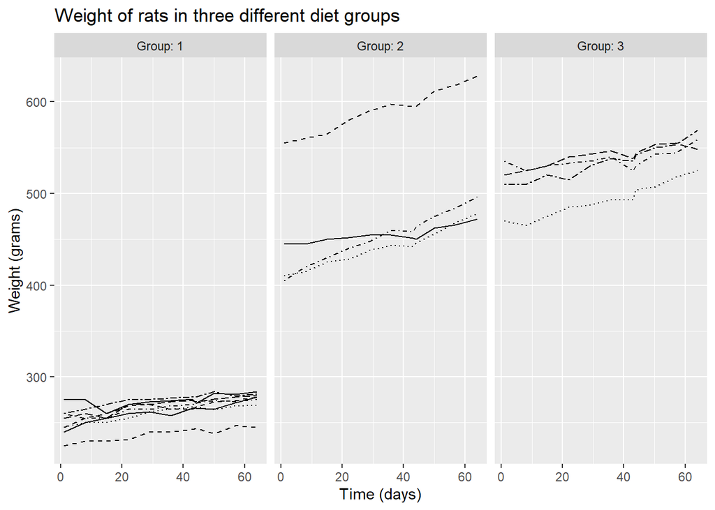

```r
ggplot(RATSL, aes(x = Time, y = Weight, linetype = ID)) +
  geom_line() +
  scale_linetype_manual(values = rep(1:10, times=4)) +
  facet_grid(. ~ Group, labeller = label_both) +
  theme(legend.position = "none") +
  scale_y_continuous(limits = c(min(RATSL$Weight), max(RATSL$Weight)), name = "Weight (grams)")+
  scale_x_continuous(name = "Time (days)")+
  ggtitle("Weight of rats in three different diet groups")
```

From the plots above, we can clearly see that there are differences between diet groups. The weight seems to be growing in each group over time. However, in group 1 the weight is quite stable (below 300g) over the time period for all rats in that group. If we compare group 1 to groups 2 and 3, we see that there is significant difference and weight is higher in groups 2 and 3 than in 1. There is also one outlier in group 2 because the weight is clearly higher than any other. If we compare groups 2 and 3 there is not so clear difference between them.

Let´s see next what happens to the plot if we standardize the weight.

```r
RATS_std <- RATSL %>%
  group_by(Time) %>%
  mutate(stdWeight = (Weight - mean(Weight))/sd(Weight) ) %>%
  ungroup()

glimpse(RATS_std)
```

```
## Rows: 176
## Columns: 6
## $ ID        <fct> 1, 2, 3, 4, 5, 6, 7, 8, 9, 10, 11, 12, 13, 14, 15, 16, 1,...
## $ Group     <fct> 1, 1, 1, 1, 1, 1, 1, 1, 2, 2, 2, 2, 3, 3, 3, 3, 1, 1, 1, ...
## $ WD        <chr> "WD1", "WD1", "WD1", "WD1", "WD1", "WD1", "WD1", "WD1", "...
## $ Weight    <int> 240, 225, 245, 260, 255, 260, 275, 245, 410, 405, 445, 55...
## $ Time      <int> 1, 1, 1, 1, 1, 1, 1, 1, 1, 1, 1, 1, 1, 1, 1, 1, 8, 8, 8, ...
## $ stdWeight <dbl> -1.0011429, -1.1203857, -0.9613953, -0.8421525, -0.881900...
```

Then I will do the plot again with standardized values

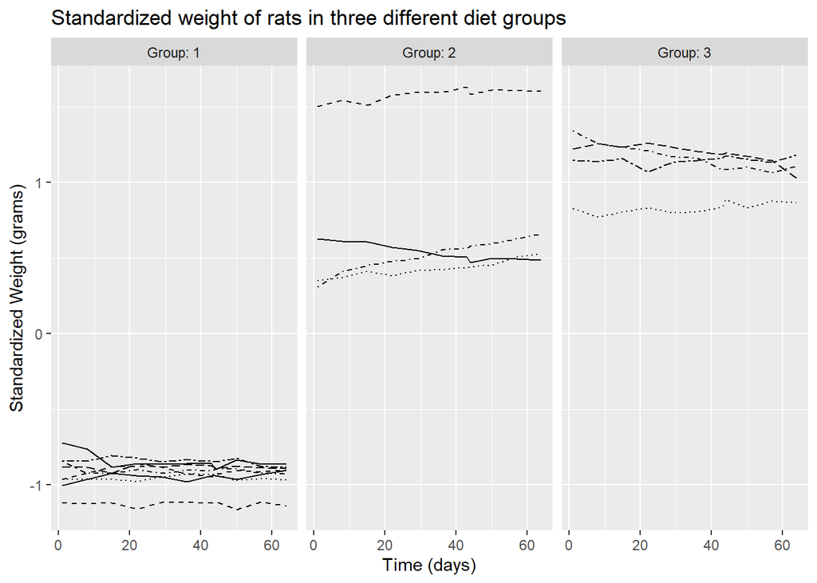

```r
ggplot(RATS_std, aes(x = Time, y = stdWeight, linetype = ID)) +
  geom_line() +
  scale_linetype_manual(values = rep(1:10, times=4)) +
  facet_grid(. ~ Group, labeller = label_both) +
  theme(legend.position = "none") +
  scale_y_continuous(name = "Standardized Weight (grams)")+
  scale_x_continuous(name = "Time (days)")+
  ggtitle("Standardized weight of rats in three different diet groups")
```

We can still see the differences between groups and the outlier but now it is not so clear, if the weight is growing over time.

Let´s do a graph showing average profiles for each diet group along with some indication of the variation of the observations at each time point.

```r
n <- RATSL$Time %>% unique() %>% length() #number of time points

RATSS <- RATSL %>% #Summary data with mean and standard error of weight by group and time
  group_by(Group, Time) %>%
  summarise( mean = mean(Weight), se = sd(Weight)/sqrt(n) ) %>%
  ungroup()
glimpse(RATSS)
```

```
## Rows: 33
## Columns: 4
## $ Group <fct> 1, 1, 1, 1, 1, 1, 1, 1, 1, 1, 1, 2, 2, 2, 2, 2, 2, 2, 2, 2, 2...
## $ Time  <int> 1, 8, 15, 22, 29, 36, 43, 44, 50, 57, 64, 1, 8, 15, 22, 29, 3...
## $ mean  <dbl> 250.625, 255.000, 254.375, 261.875, 264.625, 265.000, 267.375...
## $ se    <dbl> 4.589478, 3.947710, 3.460116, 4.100800, 3.333956, 3.552939, 3...
```

Then let´s plot the mean profiles

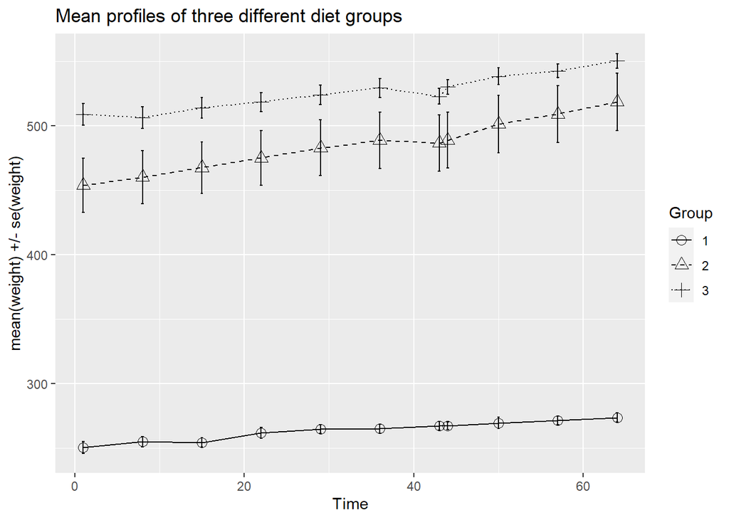

```r
ggplot(RATSS, aes(x = Time, y = mean, linetype = Group, shape = Group)) +
  geom_line() +
  scale_linetype_manual(values = c(1,2,3)) +
  geom_point(size=3) +
  scale_shape_manual(values = c(1,2,3)) +
  geom_errorbar(aes(ymin = mean - se, ymax = mean + se, linetype="1"), width=0.3) +
  theme(legend.position = c(0.8,0.8)) +
  scale_y_continuous(name = "mean(weight) +/- se(weight)")+
  theme(legend.position = "right")+
  ggtitle("Mean profiles of three different diet groups")
```

From this plot above we can see even more clearly the differences between all the diet groups and how the weight is slightly increasing over time.

Next I want to see if there are outliers in the data. I will calculate the mean for all groups over the whole time period and draw boxplots.

```r
# Creating a summary data by weight and ID with mean as the summary variable (with baseline).
RATSS_2 <- RATSL %>%
  group_by(Group, ID) %>%
  summarise( mean=mean(Weight) ) %>%
  ungroup()
glimpse(RATSS_2)
```

```
## Rows: 16
## Columns: 3
## $ Group <fct> 1, 1, 1, 1, 1, 1, 1, 1, 2, 2, 2, 2, 3, 3, 3, 3
## $ ID    <fct> 1, 2, 3, 4, 5, 6, 7, 8, 9, 10, 11, 12, 13, 14, 15, 16
## $ mean  <dbl> 261.0909, 237.6364, 260.1818, 266.5455, 269.4545, 274.7273, 2...
```

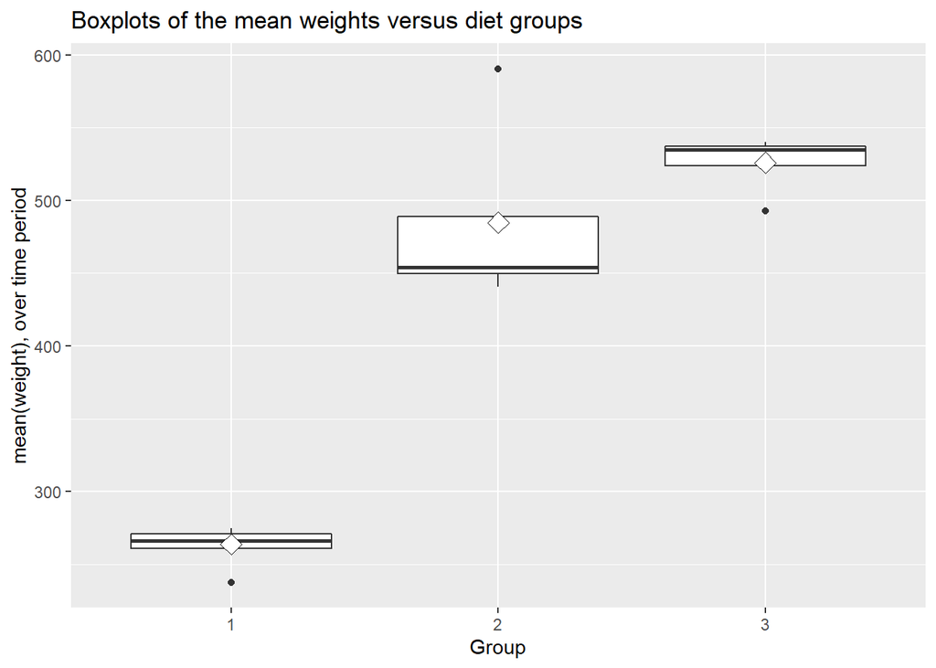

```r
# Drawing a boxplot of the mean versus group
ggplot(RATSS_2, aes(x = Group, y = mean)) +
  geom_boxplot() +
  stat_summary(fun = "mean", geom = "point", shape=23, size=4, fill = "white") +
  scale_y_continuous(name = "mean(weight), over time period")+
  ggtitle("Boxplots of the mean weights versus diet groups")
```

We can now see that there is significant outlier in the group 2 which I want to delete from the data. There are also outliers in groups 1 and 3 but they are not so significant as the one in group 2 so I will not delete them.

```r
# Creating a new data by filtering the outlier
RATSS_3 <- RATSS_2 %>%
  filter(mean < 550)
```

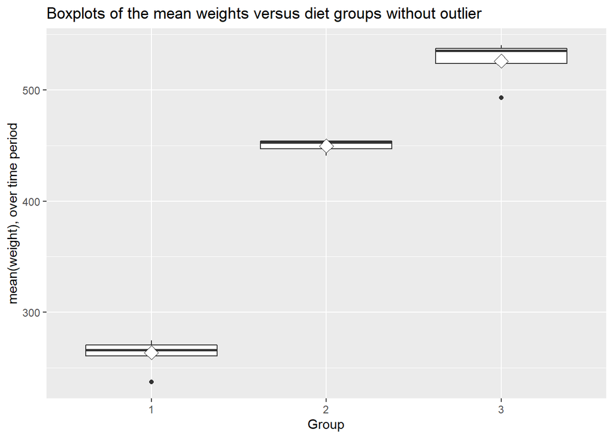

```r
# Drawing a boxplot of the mean versus group again without outlier
ggplot(RATSS_3, aes(x = Group, y = mean)) +
  geom_boxplot() +
  stat_summary(fun = "mean", geom = "point", shape=23, size=4, fill = "white") +
  scale_y_continuous(name = "mean(weight), over time period")+
  ggtitle("Boxplots of the mean weights versus diet groups without outlier")
```

From this plot we can see that the standard deviation inside the groups is quite small. But the differences between groups is seen clearly.

Even though, we can see the differences between groups quite clearly, we should run some statistical test to be sure.

Now we have more than 2 variables, so we cannot use two sample t-test to see if there are statistically significant differences between groups. I will use function aov from stats package to see if there are differences between groups.

```r
library(stats)
```

```r
dif <- aov(mean ~ Group, data = RATSS_3)
summary(dif)
```

```
##             Df Sum Sq Mean Sq F value   Pr(>F)
## Group        2 206390  103195   483.6 3.39e-12 ***
## Residuals   12   2561     213
## ---
## Signif. codes:  0 '***' 0.001 '**' 0.01 '*' 0.05 '.' 0.1 ' ' 1
```

From the summary we can see that F value of the statistical test is very high 483.6 and p-value is very small (3.39e-12) which mean that there are statistically significant differences between diet groups.

Next I will fit the linear model and see the table of variance

```r
# Fitting the linear model with the mean as the response
fit <- lm(mean ~ Group, data = RATSS_3)
summary(fit)
```

```
##
## Call:
## lm(formula = mean ~ Group, data = RATSS_3)
##
## Residuals:
##     Min      1Q  Median      3Q     Max
## -32.886  -3.080   3.273   9.250  14.386
##
## Coefficients:
##             Estimate Std. Error t value Pr(>|t|)
## (Intercept)  263.716      5.165   51.06 2.09e-15 ***
## Group2       185.739      9.890   18.78 2.90e-10 ***
## Group3       262.080      8.945   29.30 1.56e-12 ***
## ---
## Signif. codes:  0 '***' 0.001 '**' 0.01 '*' 0.05 '.' 0.1 ' ' 1
##
## Residual standard error: 14.61 on 12 degrees of freedom
## Multiple R-squared:  0.9877, Adjusted R-squared:  0.9857
## F-statistic: 483.6 on 2 and 12 DF,  p-value: 3.387e-12
```

```r
# Computing the analysis of variance table for the fitted model with anova()
anova(fit)
```

```
## Analysis of Variance Table
##
## Response: mean
##           Df Sum Sq Mean Sq F value    Pr(>F)
## Group      2 206390  103195   483.6 3.387e-12 ***
## Residuals 12   2561     213
## ---
## Signif. codes:  0 '***' 0.001 '**' 0.01 '*' 0.05 '.' 0.1 ' ' 1
```